# Trabalho 1 - Projeto de Banco de Dados

## Q9

> **Tempo sem índice:** Deu *Timeout* (mais de 60s)

> **Tempo com índice:** 12,6s

> A consulta não rodou em menos de 60 segundos (deu TIMEOUT) Pelo fato da tabela **ORDERS** não possuir nenhum índice criado. A consulta tornava-se muito custosa com isso foi criado o seguinte índice:

```sql
create index idx_order_orderkey on ORDERS(o_orderkey)
```

> **Explain**

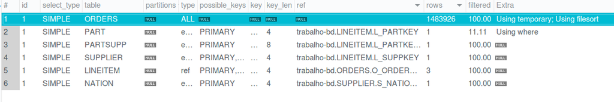

- **Execution Plan com índice criado**

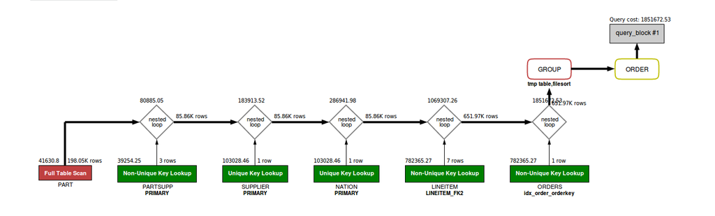

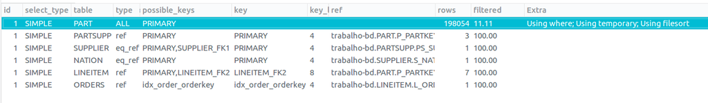

## Q10

> **Tempo sem índice:** De 2,9s a 4,4s

> **Tempo com índice:** De 2s a 2,2s

> Como já vimos, a tabela **ORDERS** não possui nenhum índice criado. com isso foi criado o seguinte índice:

```sql
create index idx_order_orderdate on ORDERS(o_orderdate);
```

> Desta forma o SGBD consegue fazer um *RANGE SCAN* nesta consulta, conforme mostrado no *EXECUTION PLAN*
- **Execution Plan**

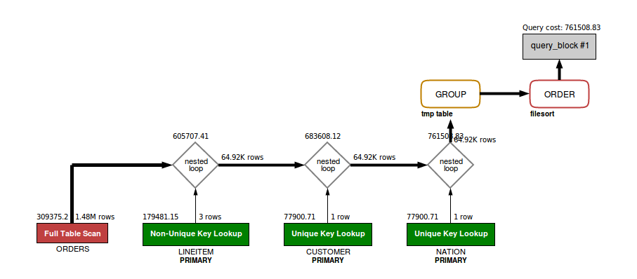

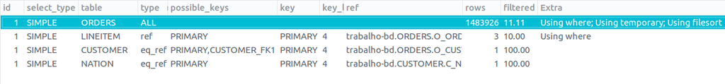

- **Execution Plan com índice criado**

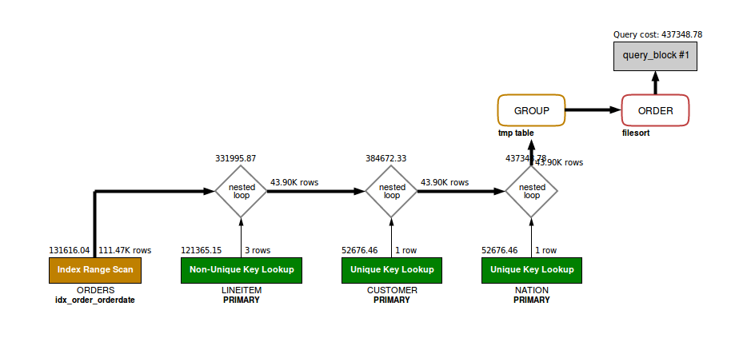

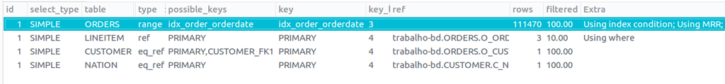

## Q11

> **Tempo sem índice:** De 2,4s a 3,1s

> **Tempo com índice:** 0,6s

> Verificamos que a tabela **PARTSUPP** não possuia um indice separado para o campo *PS_SUPPKEY* com isso foi criado o seguinte índice:

```sql
create index idx_partsupp_suppkey on PARTSUPP(ps_suppkey);
```

> Com isso conseguimos diminuir tanto o *QUERY COST* quanto o tempo da consulta
- **Execution Plan sem índice**

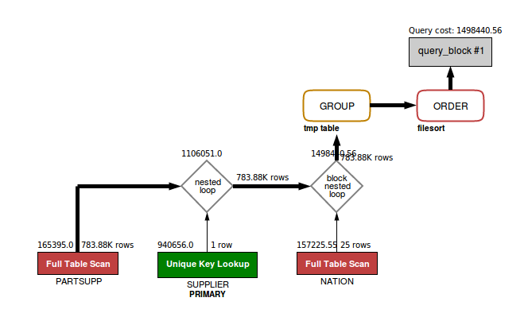

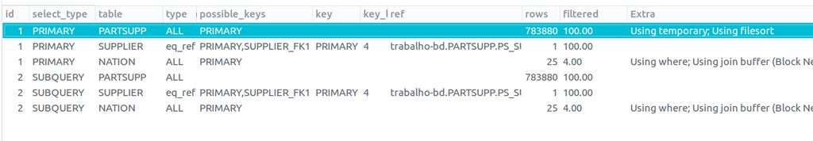

- **Execution Plan com índice criado**

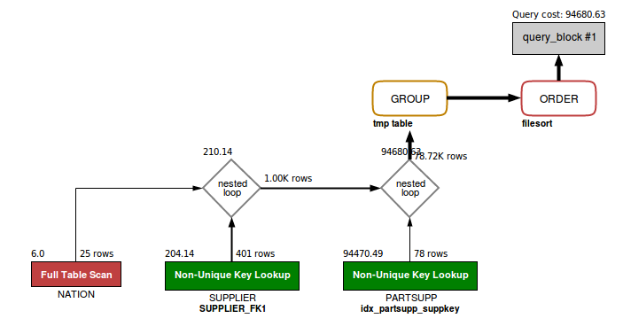

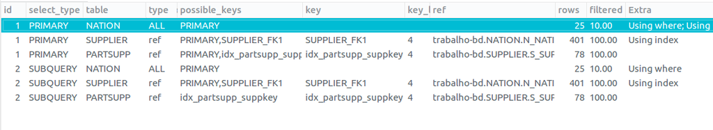

## Q12

> **Tempo sem índice:** De 11,5 a 15s

> **Tempo com índice:** 3,8s

> Mais uma vez a tabela **ORDERS** que não possui nenhum indice criado está sendo usado em uma condição de junção com isso foi criado o seguinte índice:

```sql
create index idx_order_orderkey on ORDERS(o_orderkey);
```

> Ele foi suficiente para diminuir bastante o tempo da consulta e o *QUERY COST*
- **Execution Plan sem índice**

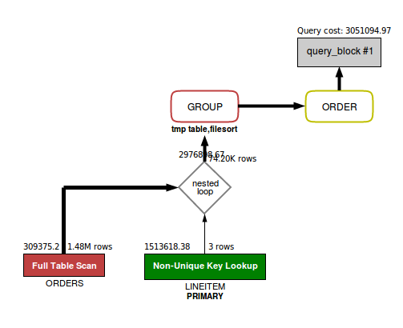

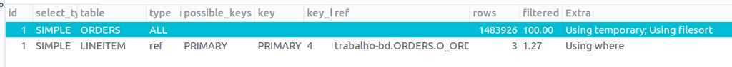

- **Execution Plan com índice criado**

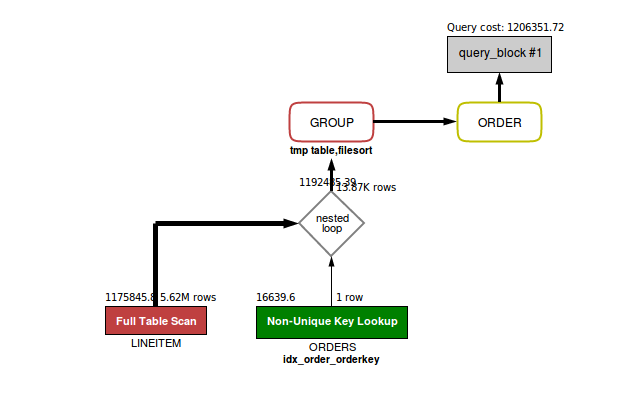

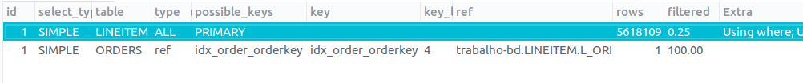

## Q13

> **Tempo sem índice:** Deu *Timeout* (mais de 60s)

> **Tempo com índice:** 14,4s

> Esta consulta também deu *TIMEOUT* A razão disso foi que mais uma vez a tabela **ORDERS** foi usada numa junção com isso foi criado o seguinte índice:

```sql
create index idx_order_custkey on ORDERS(o_custkey);
```

> Apenas isso foi suficiente para fazer a consulta rodar
- **Explain sem índice**

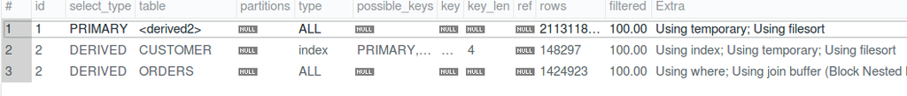

- **Execution Plan com índice criado**

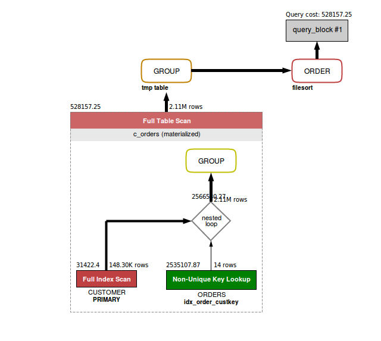

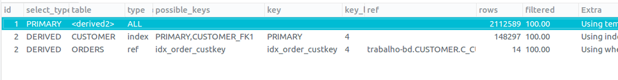

## Q14

> **Tempo sem índice:** 5,6s

> **Tempo com índice:** 1,2s

> Verificamos que poderíamos adicionar um índice para que o SGBD deixasse de fazer um *FULL SCAN* na tabela **LINEITEM** Com isso criamos o seguinte índice:

```sql
create index idx_lineitem_conditions on LINEITEM(l_shipdate, l_partkey);
```

- **Execution plain sem índice**

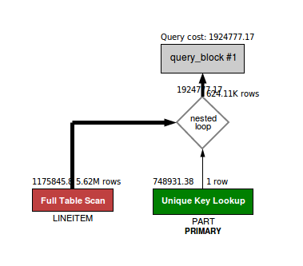

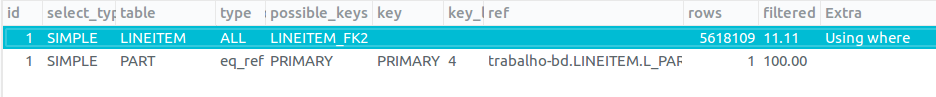

- **Execution Plan com índice criado**

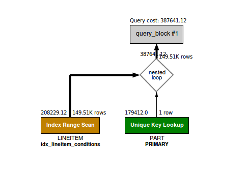

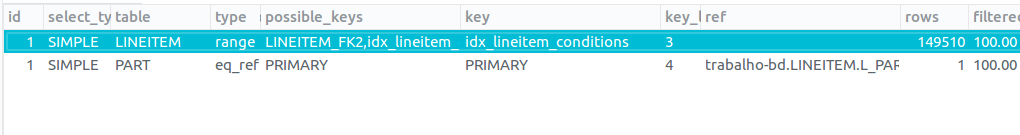

## Q15

> **Tempo sem índice:** 6,4s

> **Tempo com índice:** 5,8s

> Da mesma forma que a consulta 14, o objetivo aqui foi criar um índice que fosse capaz de trocar o *FULL SCAN* por *RANGE SCAN* Desta forma, criamos o seguinte índice:

```sql
create index idx_lineitem_shipdate on LINEITEM(l_shipdate);
```

- **Execution plain sem índice**

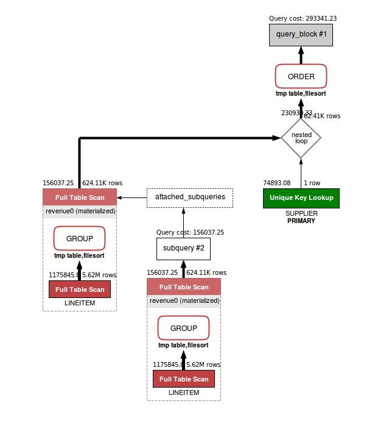

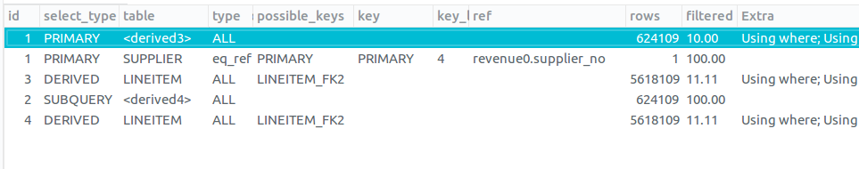

- **Execution Plan com índice criado**

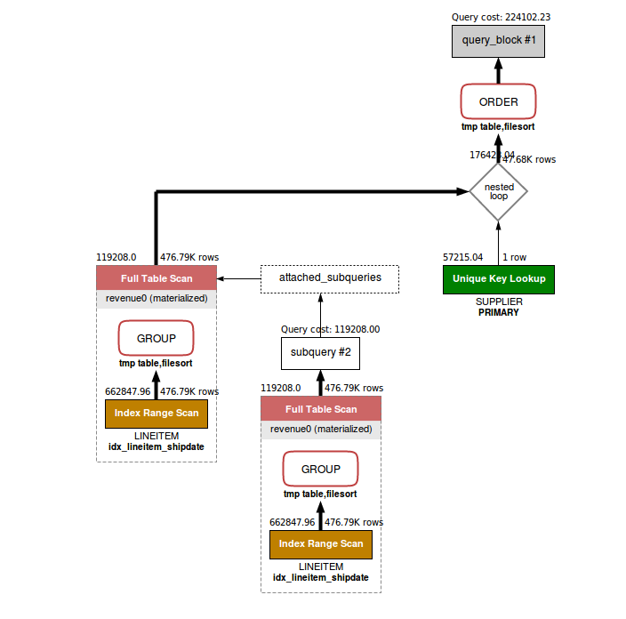

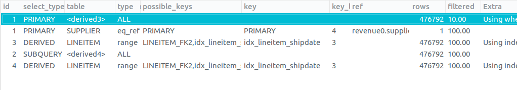

## Q16

> **Tempo sem índice:** 0,6s

> **Tempo com índice:** 0,6s

```sql
create index idx_part_size on PART(p_size);
create index idx_part_brand on PART(p_brand);
```

> Sendo o primeiro o mais relevante por possibilitar um Range Scan como mostrado no *Execution Plan*
- **Execution plain sem índice**

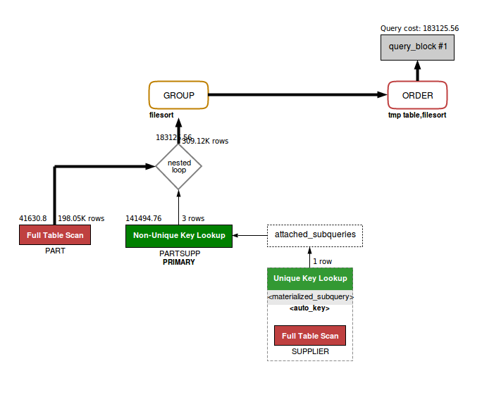

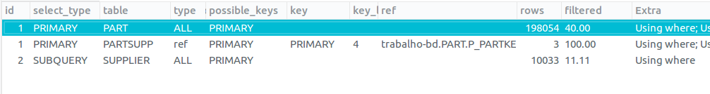

- **Execution Plan com índice criado**

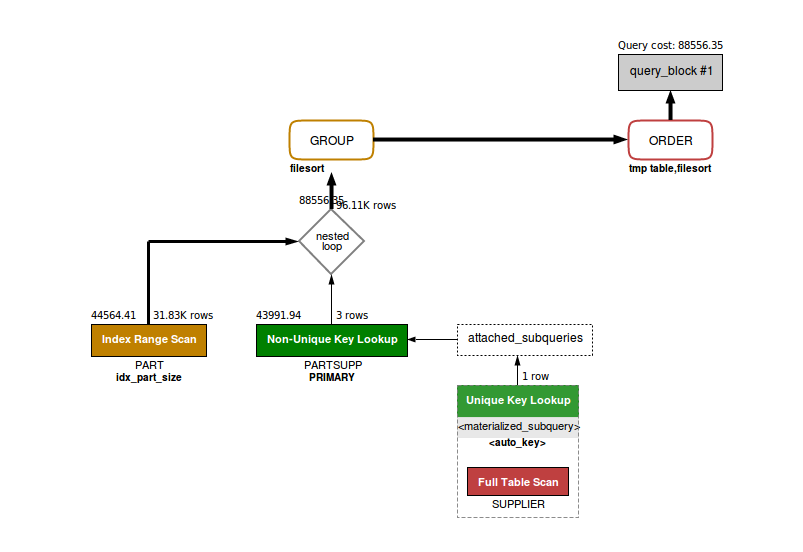

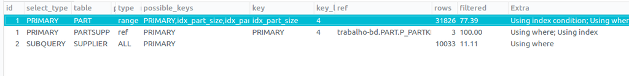

## Q17

> **Tempo sem índice:** 2,2s

> **Tempo com índice:** 1,3s

```sql
create index idx_part_container on PART(p_container);
create index idx_part_brand on PART(p_brand);
create index idx_lineitem_partkey on LINEITEM(l_partkey);
```

> O custo diminuiu bastante com a criação dos índices para a tabela **PART**. No entanto, o índice criado para a tabela **LINEITEM** não teve muito impacto, mas conseguiu diminuir minimamente o custo.
- **Execution plain sem índice**

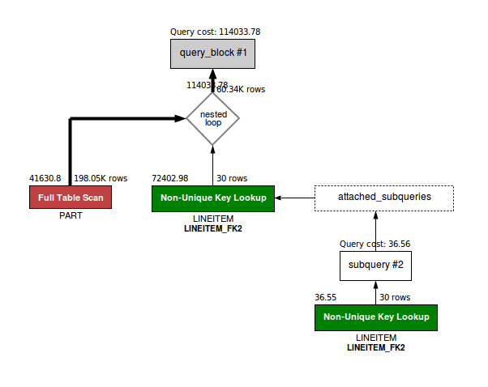

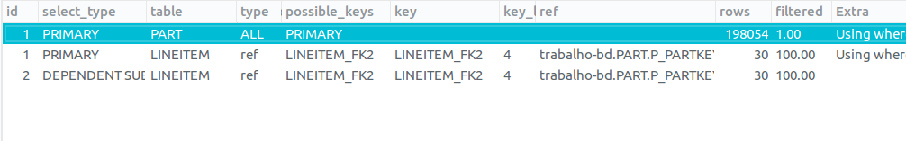

- **Execution Plan com índice criado**

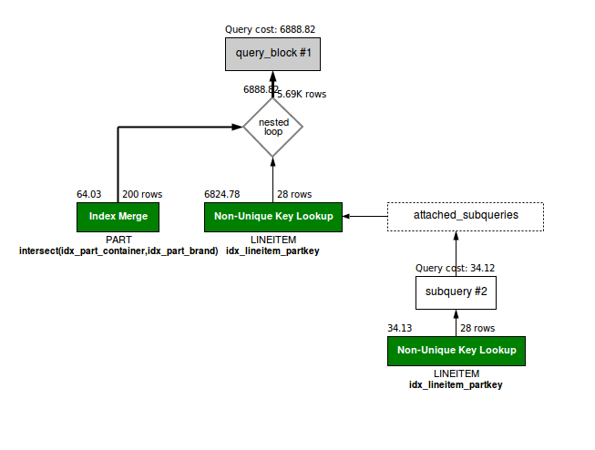

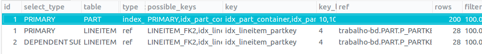

## Q18

> **Tempo sem índice:** 4,7s

> **Tempo com índice:** 3,8s

> Neste caso o uso de índice não ajudou muito. O tempo teve uma pequena variação, mas olhando para o *EXECUTION PLAN* Vemos que não houve diferença no *QUERY COST* O SGBD apenas escolheu usar o índice criado:

```sql
create index idx_lineitem_conditions on LINEITEM(l_orderkey, l_quantity);
```

- **Execution plain sem índice**

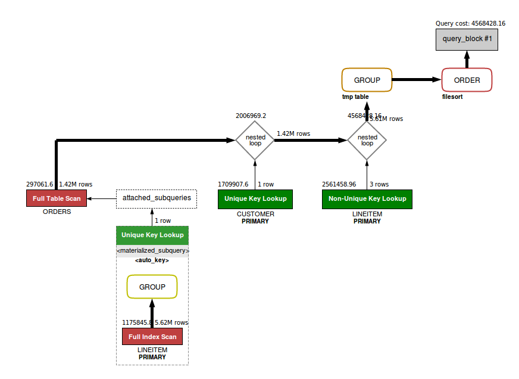

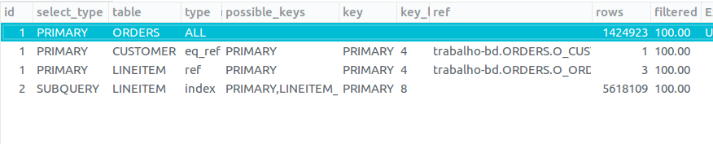

- **Execution Plan com índice criado**

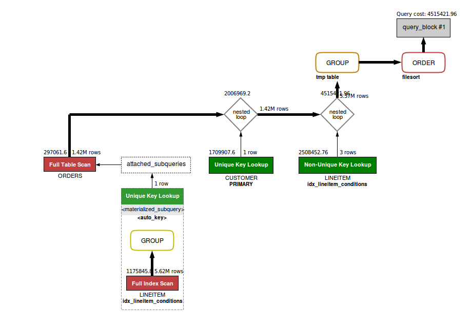

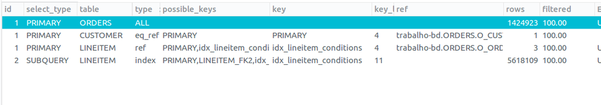

## Q19

> **Tempo sem índice:** 0,3s

> **Tempo com índice:** 0,2s

> Neste caso o objetivo foi tentar remover o *FULL SCAN* que estava sendo feito Com isso adicionamos o seguinte índice:

```sql
create index idx_part_conditions on PART(p_container, p_brand, p_size, p_partkey);
```

> O tempo de execução não mudou muito, pois já era pouco antes da criação do índice No entanto, após a criação o SGBD conseguiu fazer um *RANGE SCAN*
- **Execution plain sem índice**

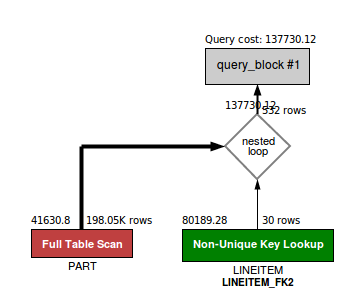

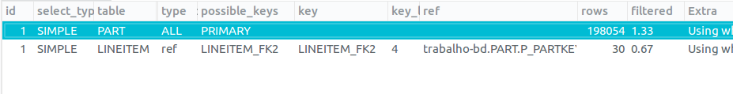

- **Execution Plan com índice criado**

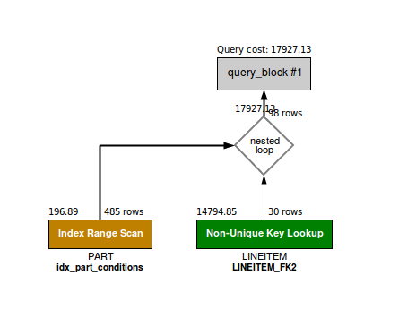

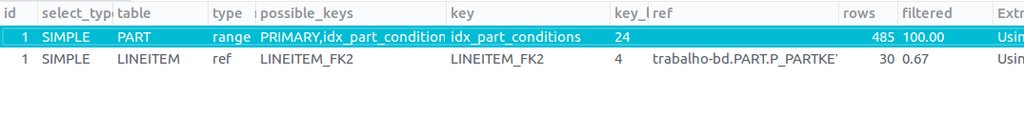

## Q20

> **Tempo sem índice:** 1,2s

> **Tempo com índice:** 1,1s

> Verificamos o SGBD estava fazendo um *FULL SCAN* na tabela **PART** Com isso decidimos criar o seguinte índice:

```sql
create index idx_part_name on PART(p_name);
```

> Após a criação do índice não houve mudança significativa no tempo da consulta, mas o *QUERY COST* diminuiu bastante
- **Execution plain sem índice**

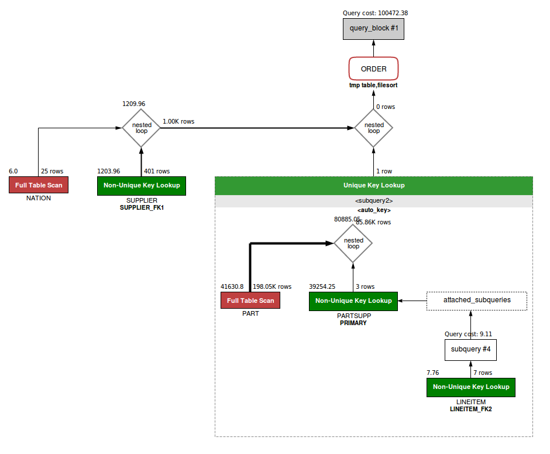

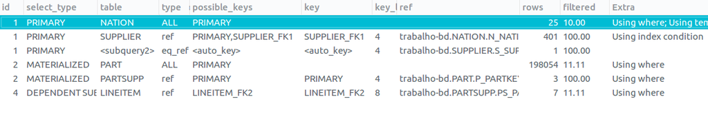

- **Execution Plan com índice criado**

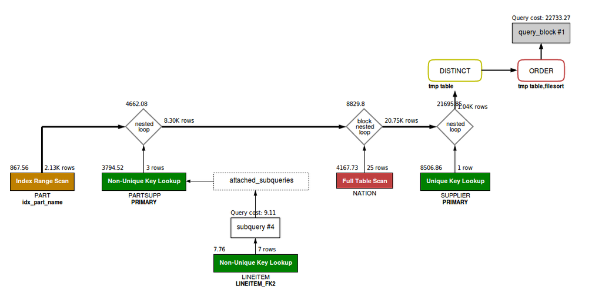

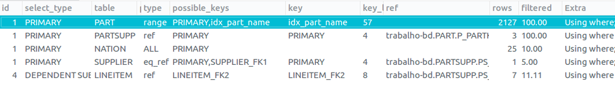

## Q21

> **Tempo sem índice:** 24,8s

> **Tempo com índice:** 23,7s

> Não houve muita melhora no tempo, o único indice que consiguiu melhorar um pouco o tempo e diminuir o *QUERY COST* foi:

```sql
create index idx_nation_name on NATION(n_name);
```

> Ainda sim, não é uma mudança tão grande, porque a tabela **NATION** tem poucos registros
- **Execution plain sem índice**

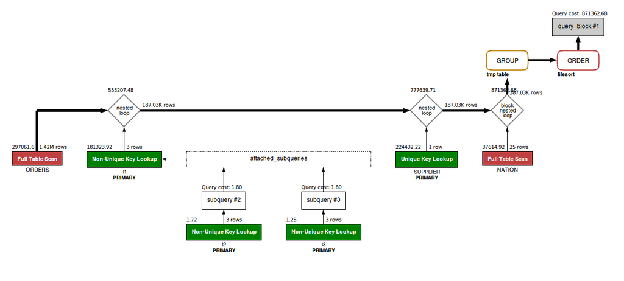

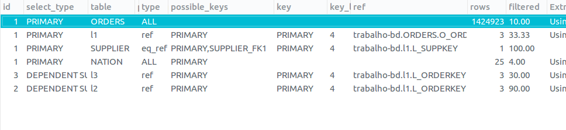

- **Execution Plan com índice criado**

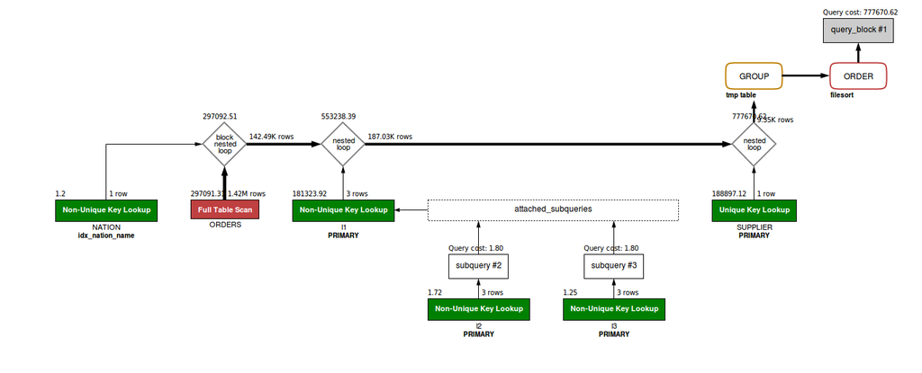

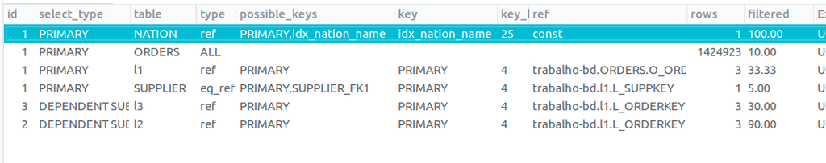

## Q22

> **Tempo sem índice:** Deu *Timeout* (mais de 60s)

> **Tempo com índice:** 0,26s

> Mais uma consulta que deu *TIMEOUT* A razão disso está no fato da tabela **ORDERS** não possuir nenhum índice

```sql
create index idx_order_custkey on ORDERS(o_custkey);
create index idx_customer_join on CUSTOMER(c_acctbal, c_phone);
```

- **Explain sem índice**

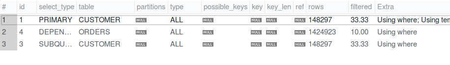

- **Execution Plan com índice criado**

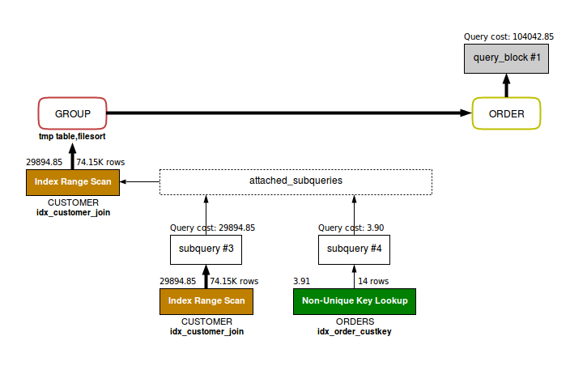

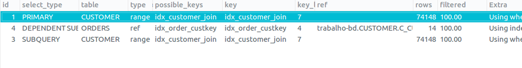